# BAYPASS_outliers_detection_new_var

Thomas Francisco

2024-04-30

BAYPASS is an outlier detection method developed by Gautier in 2015. The underlying models explicitly account for (and may estimate) the covariance structure among the population allele frequencies that originates from the shared history of the populations. There are 3 models working differently:  
- the core model: it’s an fst-scan method not taking into account the climatic or environmental variables  
- the auxiliary covariate model: a GEA method not taking into account the population structure  
- the standard covariate model: GEA method taking into account the population structure

We will use the last model: the standard covariate model to perform the outlier detection. More precisely, this model calculate a (scaled) covariance matrix between pop (that will be used as a covariate in the model to take into account the population structure). This model evaluate to which extent each markers are linearly associated with the covariates (covariance matrix and the climatic/environmental variables). The estimation of the regression coefficient of each snp with the covariates is estimated using either MCMC (not explain here) or IS (importance sampling) approximation. The IS also enables to estimate the bayes factor to evaluate the support in favor of association of each SNP i with a covariable k, i.e., to compare the model with association (βik ̸= 0) against the null model (βik = 0) (BAYPASS manual).

There is few steps to perform the outlier detection using BAYPASS:  
- format of the genomic data (with and without MAF)  
- format of the climatic data  
- run the standard covariate model with IS in ubuntu  
- analyse the results (following the BAYPASS manual)

```
1. Format of the genomic data
```

The genomic data needs to be in the format with SNP in rows with one row per SNP and in columns we have the populations (the number of columns is twice the number of populations) with 2 columns per populations (1 for each allele of a SNP). The genomic information is code in allele count at the population level, so:  
POP1 POP2 POP3 POP4 POP5 POP6  
SNP 1: 71 8 115 0 61 36 51 39 10 91 69 58  
SNP 2: 82 0 91 0 84 14 24 57 28 80 18 80

We will need to create two genomic files in this format: the file that is used for GEA and the one used to calculate the covariance matrix to take into account the population structure (this file is not filtered by MAF because MAF is important to asses population structure)

```
  - Format of the corrected MAF dataset for GEA analysis
```

```r
#meta data pop
meta_data_pop <- read.csv("C:/Users/tfrancisco/Documents/Thèse/Data/Espèces/Taxus_baccata/Populations/taxus_sample_29pop.csv",h=T,sep=";",dec=",")
#meta data indiv
meta_data_vcf=read.csv("C:/Users/tfrancisco/Documents/Thèse/Data/Espèces/Taxus_baccata/Samples/samples_taxus_baccata_adapcon_gentree.csv",h=T,sep=";",dec=",")
```

```r
#genomic data for outlier detection
load("C:/Users/tfrancisco/Documents/Thèse/Data/Espèces/Taxus_baccata/genetic_new/Gen_matrix_imp_T_Adapcon_Gentree_475_8616.Rdata")
genomic_data_maf_c <-Gen_matrix_imp_T_Adapcon_Gentree_475_8616

#genomic data with MAF (non corrected) for covariance matrix
load("C:/Users/tfrancisco/Documents/Thèse/Data/Espèces/Taxus_baccata/genetic_new/GEA/Data_geno_no_maf_c_8252SNP_452IND.Rdata")

genomic_data_no_maf_c <- Data_geno_no_maf_c_8252SNP_452IND
```

```r
genomic_data_maf_c_ID <- rownames_to_column(genomic_data_maf_c)
#name of VCF_ID to merge
names(genomic_data_maf_c_ID)[names(genomic_data_maf_c_ID) == 'rowname'] <- 'VCF_ID'

#add the population information
genomic_data_MAF_pop <- data.frame(merge(meta_data_vcf[,c(1,3)],genomic_data_maf_c_ID, "VCF_ID"))
```

```r
#this function enables to calculate the allelic count of the 1st allele of SNP from the genotypic data in format: 0, 1, 2.
reformat_genotype <- function(allele) {
  allele1 <- case_when(
    allele == " 0" ~ 2,
    allele == " 1" ~ 1,
    allele == " 2" ~ 0,
    allele == "0" ~ 2,
    allele == "1" ~ 1,
    allele == "2" ~ 0,
    TRUE ~ NA_real_
  )
  return(allele1)
}

# Apply the reformat_genotype function to SNP columns and calculate Allele2. Allele1 and 2 in two different dataframe to merge them more easily after.

#allele1
df_allele1 <- genomic_data_MAF_pop %>%
  mutate(across(starts_with("Tbac"), ~ reformat_genotype(.)))


#allele 2
df_allele2 <- df_allele1 %>%
  mutate_at(vars(starts_with("Tbac")), ~ 2 - .)#to calculate the allele2, we just did 2- the count of allele1 for each individual for each snp.


# Group by Population and summarize allele counts

#allele1
allele_counts_allele1 <- df_allele1 %>%
  group_by(Population) %>%
  summarize(
    across(starts_with("Tbac"), ~ sum(.)),
  )

#allele2
allele_counts_allele2 <- df_allele2 %>%
  group_by(Population) %>%
  summarize(
    across(starts_with("Tbac"), ~ sum(.)),
  )
```

```r
#rename allele_counts_2 to merge them with allele1
allele_counts_allele2$Population <- paste0(allele_counts_allele2$Population,"_Allele_2")

#final dataset with both allele 1 and 2

final_dtf <- rbind(allele_counts_allele1,allele_counts_allele2);row.names(final_dtf) <- final_dtf$Population

#order the population to have the format where allele1 and allele 2 for each pop are beside
final_r_order <- final_dtf[order(row.names(final_dtf)), ]

#allele in row and population*2 in columns side by side
data_allele_count_BAYPASS_MAF_c <- data.frame(t(final_r_order))

#export the data in txt
write.table(x=data_allele_count_BAYPASS_MAF_c,
  file = "C:/Users/tfrancisco/Documents/Thèse/Data/Espèces/Taxus_baccata/GEA/BAYPASS/data_allele_count_BAYPASS_MAF_c.txt",
            sep = " ",
            row.names = F,
            col.names = F)
```

The file data_allele_count_BAYPASS_MAF_c contain the genotypic data to run BAYPASS standard covariate model with IS.

```
  - Format of the genomic data for the covariance matrix (non corrected for MAF)
```

```r
genomic_data_maf_no_c_ID <- rownames_to_column(genomic_data_no_maf_c)
#name of VCF_ID to merge
names(genomic_data_maf_no_c_ID)[names(genomic_data_maf_no_c_ID) == 'rowname'] <- 'VCF_ID'

#add the population information
genomic_data_no_MAF_pop <- data.frame(merge(meta_data_vcf[,c(1,3)],genomic_data_maf_no_c_ID, "VCF_ID"))
```

```r
# Apply the reformat_genotype function to SNP columns and calculate Allele2. Allele1 and 2 in two different dataframe to merge them more easily after.

#allele1
df_allele1_no_mac <- genomic_data_no_MAF_pop %>%
  mutate(across(starts_with("Tbac"), ~ reformat_genotype(.)))


#allele 2
df_allele2_no_mac <- df_allele1_no_mac %>%
  mutate_at(vars(starts_with("Tbac")), ~ 2 - .)#to calculate the allele2, we just did 2- the count of allele1 for each individual for each snp.

# Group by Population and summarize allele counts

#allele1
allele_counts_allele1_no_mac <- df_allele1_no_mac %>%
  group_by(Population) %>%
  summarize(
    across(starts_with("Tbac"), ~ sum(.,na.rm = TRUE)),
  )

#allele2
allele_counts_allele2_no_mac <- df_allele2_no_mac %>%
  group_by(Population) %>%
  summarize(
    across(starts_with("Tbac"), ~ sum(.,na.rm = TRUE)),
  )
```

```r
#rename allele_counts_2 to merge them with allele1
allele_counts_allele2_no_mac$Population <- paste0(allele_counts_allele2_no_mac$Population,"_Allele_2")

#final dataset with both allele 1 and 2

final_dtf_no_mac <- rbind(allele_counts_allele1_no_mac,allele_counts_allele2_no_mac);row.names(final_dtf_no_mac) <- final_dtf_no_mac$Population

#order the population to have the format where allele1 and allele 2 for each pop are beside
final_r_order_no_mac <- final_dtf_no_mac[order(row.names(final_dtf_no_mac)), ]

#allele in row and population*2 in columns side by side
data_allele_count_BAYPASS_MAF_no_c <- data.frame(t(final_r_order_no_mac))

#export the data in txt
write.table(x=data_allele_count_BAYPASS_MAF_no_c,
  file = "C:/Users/tfrancisco/Documents/Thèse/Data/Espèces/Taxus_baccata/GEA/BAYPASS/data_allele_count_BAYPASS_MAF_no_c.txt",
            sep = " ",
            row.names = F,
            col.names = F)
```

data_allele_count_BAYPASS_MAF_no_c contain the genomic data used to run the core model of BAYPASS to calculate the omega matrix.

```
2. Format of the climatic data
```

```r
#climatic data
climatic_data <- read.csv("C:/Users/tfrancisco/Documents/Thèse/Data/Espèces/Taxus_baccata/Climatic_data/new_selection/Past_new_6_Climatic_data_scale_df.csv",sep=";",dec=",")

climatic_data_BAYPASS <- data.frame(t(climatic_data))
```

The units are:  
- Bio1: mean annual temperature (°C)  
- Bio2: Mean diurnal range (mean of max temp - min temp)  
- Bio4: Temperature seasonality (standard deviation *100)  
- Bio9: Mean temperature of the Driest quarter (°C)  
- Bio12: Total (annual) precipitation (mm)  
- Bio15: Precipitation seasonality (coefficient of variation)

We need to put them in the BAYPASS format that is: either 1 txt for each climatic variable with populations in columns or 1 txt with all the climatic variable in row and populations in columns

```r
write.table(x=climatic_data_BAYPASS[-c(1,2),],
  file = "C:/Users/tfrancisco/Documents/Thèse/Data/Espèces/Taxus_baccata/GEA_new_var/BAYPASS/climatic_data_BAYPASS.txt",
            sep = " ",
            row.names = F,
            col.names = F)
```

climatic_data_BAYPASS contain the climatic data used to run the standard covariate model with IS in BAYPASS.

```
3. Covariate matrix
```

We ran the core model to estimate the covariate matrix that will be used to correct for population structure.  
We used the genomic data not corrected for MAC: 8252 SNPS, 29pop with allele count at the population level -> data_allele_count_BAYPASS_MAF_no_c file The core model was ran with:  
i) 20 pilot runs of 500 iterations (to adjust proposal distributions)  
ii) a burn-in period of 5000 iterations  
iii) final MCMC sampling of 1000 parameter values sampled every 20 iterations (i.e., 20000 iterations)

The covariate matrix that is used to correct for population structure is scale directly, no need to do it.

The output results are here:

```r
omega <- as.matrix(read.table("C:/Users/tfrancisco/Documents/Thèse/Data/Espèces/Taxus_baccata/GEA/BAYPASS/covari_matrix_core_model/out_mat_omega.out"))
country_names <- climatic_data$Country
dimnames(omega)=list(country_names,country_names)
```

Now, we can visualize the matrix using plot, corrplot and heatmap as proposed by Gautier (BAYPASS Manual) and following Archambeau et al 2024.

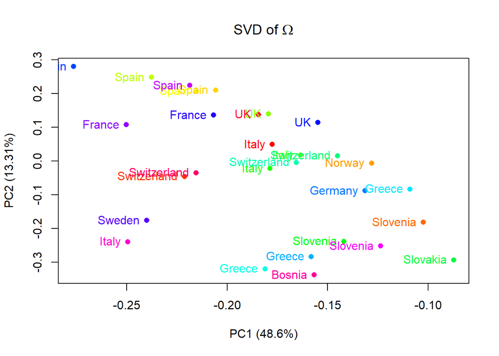

```r
#Function from Gautier 2015)
plot.omega <- function(omega,PC=c(1,2),pop.names=paste0("Pop",1:nrow(omega)),main=expression("SVD of "*Omega),col=rainbow(nrow(omega)),pch=16,pos=2){
  om.svd=svd(omega)
  eig=om.svd$d
  pcent.var=100*eig/sum(eig)
  plot(om.svd$u[,PC],main=main,pch=pch,col=col,
       xlab=paste0("PC",PC[1]," (",round(pcent.var[PC[1]],2),"%)"),
       ylab=paste0("PC",PC[2]," (",round(pcent.var[PC[2]],2),"%)")
  )
  text(om.svd$u[,PC[1]],om.svd$u[,PC[2]],pop.names,col=col,pos=pos)
  list(PC=om.svd$u,eig=eig,pcent.var=pcent.var)
}

# Using SVD decomposition
SVD_decomposition_omega_matrix <- plot.omega(omega=omega,pop.names=country_names)
```

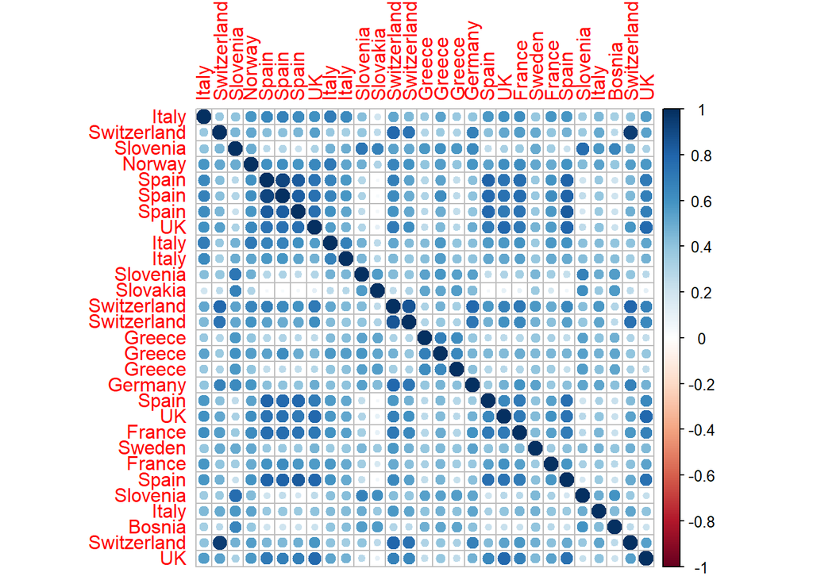

```r
# as a correlation plot
cor_mat <- cov2cor(omega)
corrplot::corrplot(cor_mat)
```

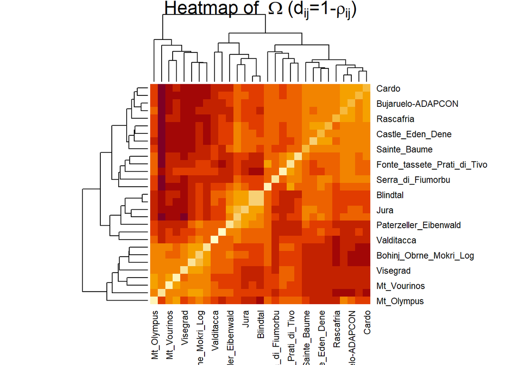

```r
# corrplot(cor_mat,method="color",mar=c(2,1,2,2)+0.1,
# main=expression("Correlation map based on"~hat(Omega)))

# as a heatmap and hierarchical clustering tree (using the average agglomeration method)
##we use the population names
pop_names <- climatic_data$Population
dimnames(omega)=list(pop_names,pop_names)

#cor matrix
cor_mat <- cov2cor(omega)

hclust_ave <- function(x) hclust(x, method="average")
Heatmap_omega_matrix<-heatmap(1-cor_mat,hclustfun = hclust_ave,
main=expression("Heatmap of "~hat(Omega)~"("*d[ij]*"=1-"*rho[ij]*")"))
```

We can see that the plot of the omega matrix is very similar to what found using a PCA with the 2 firsts axis. The correction for the population structure in BAYPASS is then similar to pRDA, LFMM and GF corrected.

```
4. Run the standard covariate model with IS in ubuntu
```

We need to run few times the IS models to see if output of the different run are consistent. We will interprete the Bayes factor (BF) and the eBPis (empirical bayesian pvalues)

First, we extract the BF and eBPis from the BAYPASS output (out_BAYPASS_outliers_ide_{seed}_summary_betai_reg.out)

```r
#names snp
names_snps <- colnames(genomic_data_maf_c)

#name climatic data
  climatic_variables <- colnames(climatic_data)
  COVARIABLE <- c(1,2,3,4,5,6) #to merge with output results of BAYPASS and have the name of the climatic variables
climatic_variables_merge <- data.frame(climatic_variables[-c(1,2)], COVARIABLE)

#only the name of the variables
names_climatic_variables <- climatic_variables[-c(1,2)]
```

```r
for(x in 1:5){
  seed <- x+11#because the selected seeds of the runs are: 12 to 16
  output_BAYPASS_run <- read.table(paste0("C:/Users/tfrancisco/Documents/Thèse/Results/species/taxus/GEA_new_var/BAYPASS/runs/out_BAYPASS_outliers_ide_",seed,"_summary_betai_reg.out"),h=T)

  #add the name of the climatic variables
  BAYPASS_clim <- merge(climatic_variables_merge,output_BAYPASS_run,"COVARIABLE")

BAYPASS_clim$climatic_variables..c.1..2.. <- as.factor(BAYPASS_clim$climatic_variables..c.1..2..)

#add names snps
subset_name <- paste0("RUN_",x, "_BAYPASS_results") # Name the output dataframe of the loop

  Data_results <- BAYPASS_clim %>%
    group_by(climatic_variables..c.1..2..) %>%
    mutate(names_snps = names_snps) %>%
    ungroup()

  assign(subset_name, Data_results)
}

names_subset_data_frame <- c("RUN_1_BAYPASS_results","RUN_2_BAYPASS_results","RUN_3_BAYPASS_results","RUN_4_BAYPASS_results","RUN_5_BAYPASS_results")
```

We also add the run info for BF and for EBpis.

```r
## we also add the RUN info
    for (x in 1:5) {
      var <- paste0("RUN_",x,"_BAYPASS_results")
    # Create the new dataframe name
    names_final <- paste0(var, "_final")

    # Extract the dataframe using get
    data <- get(var)

    name_BF.dB. <- paste0("BF_RUN",x)
    nam_eBPis <- paste0("eBPis_RUN",x)

    # Mutate the data
    names(data)[names(data)== "BF.dB."] <- name_BF.dB.
    names(data)[names(data)== "eBPis"] <- nam_eBPis

    # Assign the mutated data to a new dataframe
    assign(names_final, data)
    }
```

Finally, we can merge all the runs in on dataframe

```r
#merge all runs
data_tot_results_allRUNs <- cbind(RUN_1_BAYPASS_results_final[,c(12,2,8,11)],RUN_2_BAYPASS_results_final[,c(8,11)],RUN_3_BAYPASS_results_final[,c(8,11)],RUN_4_BAYPASS_results_final[,c(8,11)],RUN_5_BAYPASS_results_final[,c(8,11)])
```

```
5. Check the results across runs
```

Now, we want to see if the runs gave us similar results. To do this, we calculated the correlation of the values of BF and EBpis for each runs for each climatic variable. First, we need to subset the all runs dataset based on climatic variable to have 1 dataset for each climatic variable.

```r
#subset the results at the climatic variable scale to compare values between runs
for(var in names_climatic_variables){
  subset_name <- paste0(var, "_BAYPASS_all_runs") #name the output dataframe of the loop
  assign(subset_name, subset(data_tot_results_allRUNs, climatic_variables..c.1..2.. == var))#assign the name to the dataframe in a loop
}
```

```r
#list of dataset with data of all run for each climatic data
final_names_dataframe <- c("Annual_Tc_BAYPASS_all_runs","Diurnal_range_Tc_BAYPASS_all_runs","Tc_Seasonality_BAYPASS_all_runs","Tc_driest_quarter_BAYPASS_all_runs","Annual_P_BAYPASS_all_runs","P_Seasonality_BAYPASS_all_runs")
#name climatic data
names_climatic_variables <- colnames(climatic_data[,-c(1,2)])
```

Then, we want to see if these values are consistent across runs by testing the correlation of the values across runs:

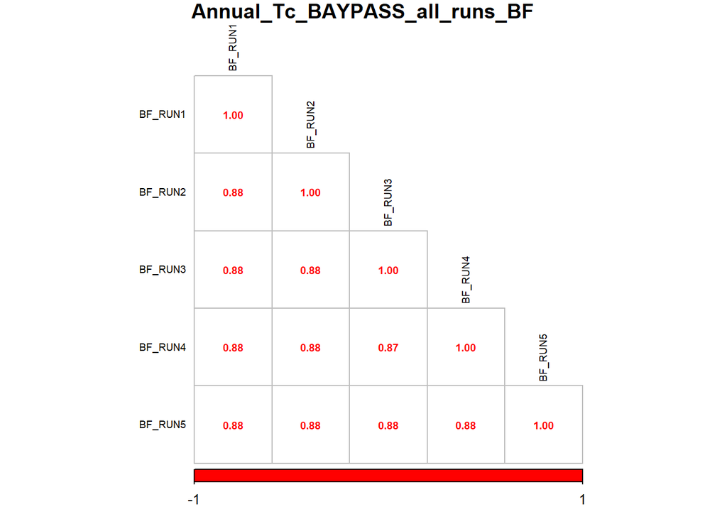

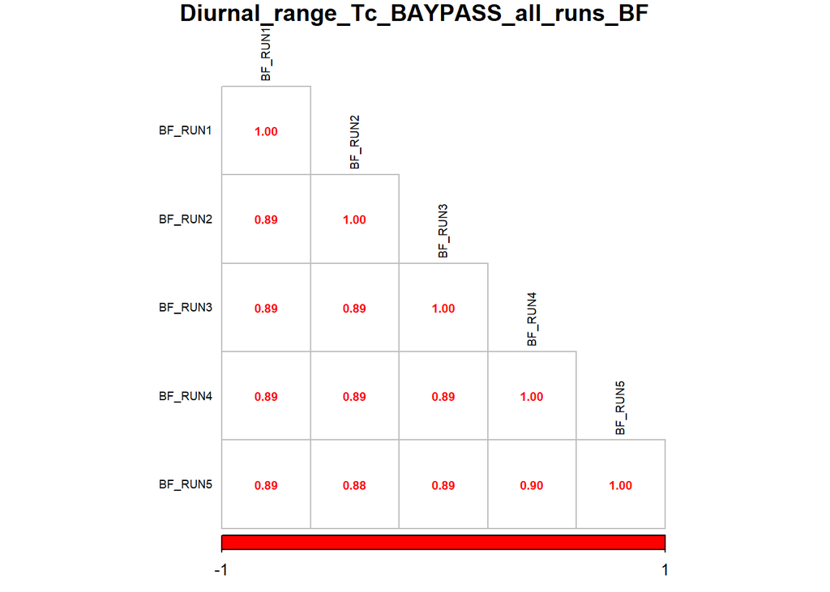

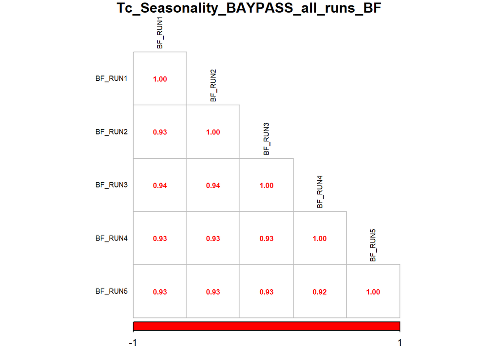

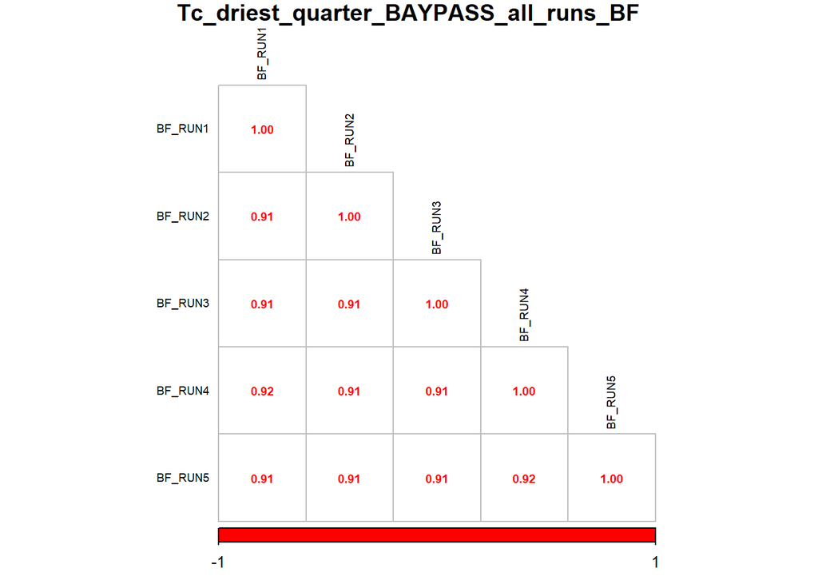

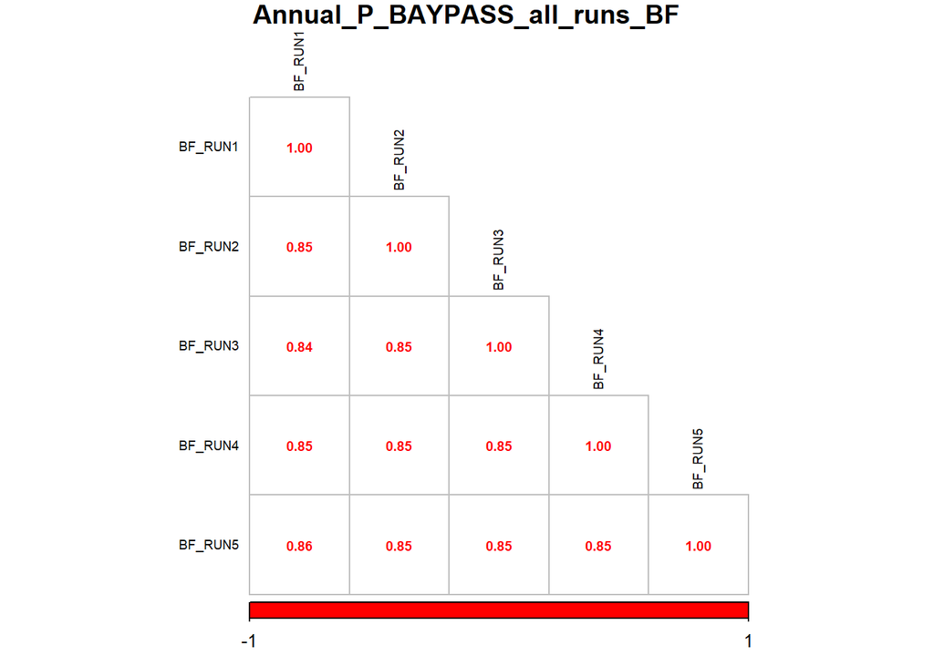

```r
#correlation between runs for BF
for(x in 1:5){
  var <- final_names_dataframe[x]

  #names of the corr matrix for each biovariable
  names_corr <- paste0("correlation_",var,"_BF")
  #title of corrplot
  title <- (paste0(var,"_BF"))

  #group for each bio var with the values of Bayes factor only
corr_bio <- cor(get(var)[, grepl("BF", names(get(var)))])

#name the corr_bio with names_corr
assign(names_corr,corr_bio)

#plot corrplot
corr_plot <- corrplot(get(names_corr), method = "number", addrect = 2, col = c("red", "white", "red"), type = "lower", tl.col = "black", tl.cex = 0.6, number.cex = 0.6, title = title,mar=c(0,0,1,0) )

#save
png(paste0("C:/Users/tfrancisco/Documents/Thèse/Results/species/taxus/GEA_new_var/BAYPASS/correlation_BF_values_across_runs_",names_climatic_variables[x],".png"));corr_plot <- corrplot(get(names_corr), method = "number", addrect = 2, col = c("red", "white", "red"), type = "lower", tl.col = "black", tl.cex = 0.6, number.cex = 0.6, title = title,mar=c(0,0,1,0) );dev.off()
}
```

```r
for(var in final_names_dataframe){
  #names of the corr matrix for each biovariable
  names_corr <- paste0("correlation_",var,"_eBPis")
  #title of corrplot
  title <- (paste0(var,"_eBPis"))

#group for each bio var with the values of empirical bayesian pvalues only
corr_bio <- cor(get(var)[, grepl("eBPis", names(get(var)))])

#name the corr_bio with names_corr
assign(names_corr,corr_bio)

#plot corrplot
#corr_plot <- corrplot(get(names_corr), method = "number", addrect = 2, col = c("red", "white", "red"), type = "lower", tl.col = "black", tl.cex = 0.6, number.cex = 0.6, title = title,mar=c(0,0,1,0) )

}
```

```
6. Outliers identification:
```

This is the last step, we need to choose the candidates based on a threshold. Gautier 2015 suggested to use the Jeffreys’rule (Jeffreys 1961) who provides a useful decision criterion to quantify the strength of evidence (here in favor of association of the SNP with the covariable), using the following dB unit scale:  
- 10 < BF < 15 = strong evidence  
- 15 < BF < 20 = very strong evidence  
- BF > 20 = decisive evidence

We could also use the EBpis with values > 3 = candidates as in Ruiz Daniels et al. (2019). We could also take the top 1%, top 0.5% or 100 SNPs with higher correlation with climatic variables.

First, we need to perform the mean of the BF values across runs for each SNPs

```r
final_names_dataframe <- c("Annual_Tc_BAYPASS_all_runs","Diurnal_range_Tc_BAYPASS_all_runs","Tc_Seasonality_BAYPASS_all_runs","Tc_driest_quarter_BAYPASS_all_runs","Annual_P_BAYPASS_all_runs","P_Seasonality_BAYPASS_all_runs")

#mean BF values
for(data in final_names_dataframe){
  #names of the corr matrix for each biovariable
  names_corr <- paste0("mean_",data,"_BF_values")

  #select only the BF values
  dataset <- get(data)[, grepl("BF", names(get(data)))]

  #mean
  mean_BF_values <- data.frame(names_snps,rowMeans(dataset)); colnames(mean_BF_values)=c("names_snps","BF_values")


#name the corr_bio with names_corr
assign(names_corr,mean_BF_values)

}

list_mean_BF_clim <- c("mean_Annual_Tc_BAYPASS_all_runs_BF_values","mean_Diurnal_range_Tc_BAYPASS_all_runs_BF_values","mean_Tc_Seasonality_BAYPASS_all_runs_BF_values","mean_Tc_driest_quarter_BAYPASS_all_runs_BF_values","mean_Annual_P_BAYPASS_all_runs_BF_values","mean_P_Seasonality_BAYPASS_all_runs_BF_values")
```

Then, we can search for candidates using a BF threshold of 10 for each climatic variable.

```r
thres_BF <- 10 #threshold of BF

for(x in 1:6){
  #names of the corr matrix for each biovariable
  names_climatic_var <- names_climatic_variables[x]
  data <- get(list_mean_BF_clim[x])

 selection_outliers <- data.frame(Loci=data$names_snps[which(data$BF_values>thres_BF)],BF = data$BF_values[which(data$BF_values>thres_BF)], climatic_variables=names_climatic_var)

 assign(paste0("names_outliers_",names_climatic_var),selection_outliers)

 # Count the number of candidates for each climatic variable
  count <- data.frame(Climatic_variable=names_climatic_var,Number_outliers=nrow(selection_outliers))

  #name the corr_bio with names_corr
assign(paste0("outliers_",names_climatic_var),count)
}
  # Combine the results for each climatic variable to see the number of candidates
  outliers_summary_BF10 <- rbind(outliers_Annual_Tc,outliers_Diurnal_range_Tc,outliers_Tc_Seasonality,outliers_Tc_driest_quarter,outliers_Annual_P,outliers_P_Seasonality)


#name of the candidates
  outliers_names_summary_BF_10 <- rbind(names_outliers_Annual_Tc,names_outliers_Diurnal_range_Tc,names_outliers_Tc_Seasonality,names_outliers_Tc_driest_quarter,names_outliers_Annual_P,names_outliers_P_Seasonality)



  #finally we can search for same candidates across climatic variables

duplicated_loci_BF10 <- duplicated(outliers_names_summary_BF_10$Loci) | duplicated(outliers_names_summary_BF_10$Loci, fromLast = TRUE)

# Subset the data frame to show only the duplicated loci
duplicated_outliers_BF10 <- outliers_names_summary_BF_10[duplicated_loci_BF10, ]

#Number of candidates:
nrow(outliers_names_summary_BF_10)
```

```
## [1] 67
```

```r
#at the climatic var scale
outliers_summary_BF10
```

```
##   Climatic_variable Number_outliers
## 1         Annual_Tc               9
## 2  Diurnal_range_Tc               7
## 3    Tc_Seasonality              23
## 4 Tc_driest_quarter               8
## 5          Annual_P               3
## 6     P_Seasonality              17
```

Finally, we save the set of candidates for downstream analysis

```r
outliers_T_adapcon_gentree_BAYPASS_BF_10 <- outliers_names_summary_BF_10[,-2]

#write_xlsx(outliers_T_adapcon_gentree_BAYPASS_BF_10,"C:/Users/tfrancisco/Documents/Thèse/Results/species/taxus/GEA_new_var/outliers/outliers_T_adapcon_gentree_BAYPASS_BF_10.xlsx")
save(outliers_T_adapcon_gentree_BAYPASS_BF_10, file="C:/Users/tfrancisco/Documents/Thèse/Results/species/taxus/GEA_new_var/outliers/outliers_T_adapcon_gentree_BAYPASS_BF_10.Rdata")
```

We can also make a less conservative dataset with a threshold of BF>8:

```r
thres_BF <- 8 #relax threshold


for(x in 1:6){
  #names of the corr matrix for each biovariable
  names_climatic_var <- names_climatic_variables[x]
  data <- get(list_mean_BF_clim[x])

 selection_outliers <- data.frame(Loci=data$names_snps[which(data$BF_values>thres_BF)],BF = data$BF_values[which(data$BF_values>thres_BF)], climatic_variables=names_climatic_var)

 assign(paste0("names_outliers_",names_climatic_var),selection_outliers)

 # Count the number of candidates for each climatic variable
  count <- data.frame(Climatic_variable=names_climatic_var,Number_outliers=nrow(selection_outliers))

  #name the corr_bio with names_corr
assign(paste0("outliers_",names_climatic_var),count)
}
  # Combine the results for each climatic variable to see the number of candidates
  outliers_summary_BF_8 <- rbind(outliers_Annual_Tc,outliers_Diurnal_range_Tc,outliers_Tc_Seasonality,outliers_Tc_driest_quarter,outliers_Annual_P,outliers_P_Seasonality)


#name of the candidates

  outliers_names_summary_BF8 <- rbind(names_outliers_Annual_Tc,names_outliers_Diurnal_range_Tc,names_outliers_Tc_Seasonality,names_outliers_Tc_driest_quarter,names_outliers_Annual_P,names_outliers_P_Seasonality)



  #finally we can search for same candidates across climatic variables

duplicated_loci_BF_8 <- duplicated(outliers_names_summary_BF8$Loci) | duplicated(outliers_names_summary_BF8$Loci, fromLast = TRUE)

# Subset the data frame to show only the duplicated loci
duplicated_outliers_BF_8 <- outliers_names_summary_BF8[duplicated_loci_BF_8, ]

#Number of candidates:
outliers_summary_BF_8
```

```
##   Climatic_variable Number_outliers
## 1         Annual_Tc              13
## 2  Diurnal_range_Tc              17
## 3    Tc_Seasonality              35
## 4 Tc_driest_quarter              20
## 5          Annual_P              13
## 6     P_Seasonality              35
```

```r
#at the climatic var scale
nrow(outliers_names_summary_BF8)
```

```
## [1] 133
```

Finally, we save the set of candidates for downstream analysis

```r
outliers_T_adapcon_gentree_BAYPASS_BF_8 <- outliers_names_summary_BF8[,-2]

#write_xlsx(outliers_T_adapcon_gentree_BAYPASS_BF_8,"C:/Users/tfrancisco/Documents/Thèse/Results/species/taxus/GEA/outliers/outliers_T_adapcon_gentree_BAYPASS_BF_8.xlsx")
save(outliers_T_adapcon_gentree_BAYPASS_BF_8, file="C:/Users/tfrancisco/Documents/Thèse/Results/species/taxus/GEa_new_var/outliers/outliers_T_adapcon_gentree_BAYPASS_BF_8.Rdata")
```

Other way of identifying outliers: overlapping SNPs of 5 runs like for GF and not the mean values of BF.

```r
list_clim <- c("Annual_Tc","Diurnal_range_Tc","Tc_Seasonality","Tc_driest_quarter","Annual_P","P_Seasonality")
list_runs <- c("RUN_1_BAYPASS_results","RUN_2_BAYPASS_results","RUN_3_BAYPASS_results","RUN_4_BAYPASS_results","RUN_5_BAYPASS_results")

for(x in 1:length(list_runs)){

  data <- get(list_runs[x])

for(i in 1:length(list_clim)){

  clim_name <- list_clim[i]

  data_clim <- data %>% filter(climatic_variables..c.1..2.. == clim_name)

 #BF values > 8
outliers_BF_8 <- data_clim[,c(12,2,8)] %>% filter(BF.dB.> 8) %>% pull(names_snps)

 assign(paste0("Run",x,"_outliers_BF_8_",clim_name),outliers_BF_8)

 #BF values > 10
outliers_BF_10 <- data_clim[,c(12,2,8)] %>% filter(BF.dB.> 10) %>% pull(names_snps)

 assign(paste0("Run",x,"_outliers_BF_10_",clim_name),outliers_BF_10)

  }
}
```

```r
list_threshold <- c(8,10)

for(i in 1:length(list_threshold)){

threshold <- list_threshold[i]

for(x in 1:length(list_clim)){

  clim_var <- list_clim[x]
  data1 <- get(paste0("Run",1,"_outliers_BF_",threshold,"_",clim_var))
  data2 <- get(paste0("Run",2,"_outliers_BF_",threshold,"_",clim_var))
  data3 <- get(paste0("Run",3,"_outliers_BF_",threshold,"_",clim_var))
  data4 <- get(paste0("Run",4,"_outliers_BF_",threshold,"_",clim_var))
  data5 <- get(paste0("Run",5,"_outliers_BF_",threshold,"_",clim_var))

  #Select only the candidates identified in all 5 runs
outliers_set <- Reduce(intersect, list(data1,data2,data3,data4,data5))

  assign(paste0("outliers_",clim_var,"_",threshold),outliers_set)

  }
}
```

See the final set of outliers

```r
list_threshold <- c(8,10) # Replace with your actual threshold values
clim_vars <- c("Annual_Tc", "Diurnal_range_Tc", "Tc_Seasonality", "Tc_driest_quarter", "Annual_P", "P_Seasonality")

df_tot_outliers_list <- list()

for (x in 1:length(list_threshold)) {
  threshold <- list_threshold[x]
  combined_data <- data.frame()

  for (var in clim_vars) {
    data <- data.frame(set = get(paste0("outliers_", var, "_", threshold)))
    data$var <- var
    combined_data <- rbind(combined_data, data)
  }

  unique_data <- combined_data[!duplicated(combined_data$set),]  # Ensuring unique rows
  df_tot_outliers_list[[threshold]] <- unique_data

  assign(paste0("df_tot_outliers_", threshold), unique_data)
}
```